# s08 — the multi-mapping confounder: recovery vs reference mappability (chr19)

gwct

10/26/2026 13:04 EDT

```r
knitr::opts_chunk$set(echo = TRUE, warning = FALSE, message = FALSE, fig.align = "center")
library(ggplot2); library(dplyr); library(tidyr); library(readr)
source("analyses/lib/design.r")   # bartheme(), corecol(); knit from the project root
```

**Provenance**

- **Rendered from commit** `761a36dcb53d` (branch `mason2-sims`) on 2026-10-26 13:04
- **This notebook:** notebook as committed
- **Analysis code:** no uncommitted edits under `analyses/`
- Each data file’s producing script and command: the section’s `MANIFEST.yaml`

# 1 Question & design

There is a confounder that has nothing to do with how divergent the sample is: **where the reference itself is repetitive, a read cannot be uniquely placed.** In such regions a 150 bp read fits several locations, `bwa` assigns low MAPQ, the MQ ≥ 20 filter drops it, and the variant there cannot be called — *no matter how similar the sample is to the reference*. This is the mechanism behind segmental-duplication / “difficult region” variant-calling failures, and it is a property of the **reference**, not the sample. (It is *not* something a sample-side duplication reproduces: a duplication of unique sequence still maps uniquely to the single reference copy — multi-mapping requires the *reference* to contain the repeat.)

We measure it directly with the real repeat structure of chr19:

- **Mappability** (`GenMap`, K = 100, E = 2, computed on **chr19 alone** — reads are mapped to chr19 only, so mappability must be chr19-internal): value = 1 / (number of near-identical 100-mer copies within chr19). **1.0 = unique, 0.5 ≈ 2 copies, < 0.2 ≈ ≥ 5 copies.** chr19 is **94.5 % unique**; ~5.5 % is repetitive and **3.8 % is highly repetitive (< 0.2)** — a minority of the genome, but a real one, and enriched for exactly the hard cases.
- **Recovery** reuses the **s01** SNP-only calls (homogeneous divergence D ∈ {0.02, 0.06, 0.10}, 30×, seed 42) so the divergence axis is clean. Each divergent SNP truth site is labeled with the mappability at its position and its recovery is scored per caller × divergence × iteration (`scripts/mappability_recovery.py`). Three bins: **unique / repetitive / highly repetitive.**

```r
lev <- c("unique (1.0)", "repetitive (0.2-1.0)", "highly repetitive (<0.2)")
mr <- read_csv("analyses/s08-mappability/results/s08-mappability-recovery.csv") %>%
  mutate(caller = factor(caller, levels = c("gatk", "bcftools", "freebayes")),
         iteration = factor(iteration),
         divergence = as.numeric(divergence),
         map_bin = factor(map_bin, levels = lev))
mcols <- setNames(corecol(pal = "wilke", numcol = 3), lev)
```

# 2 Recovery falls with mappability, at every divergence

Single-shot (iteration 1) SNP recall against divergence, split by local mappability. The three lines separate at *every* divergence — the gap is already open at D = 0.02, where reference bias is otherwise mild — so this is a genuine **mapping-ambiguity** effect, not a divergence effect. And the two stack: the worst case is repetitive **and** divergent.

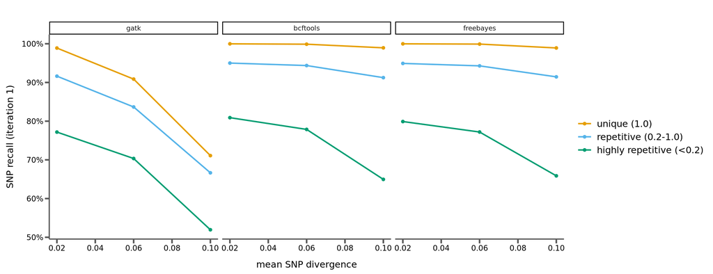

```r
ggplot(mr %>% filter(iteration == "1"),
       aes(divergence, recall, color = map_bin)) +
  geom_line(linewidth = 0.9) + geom_point(size = 1.6) +
  scale_color_manual(values = mcols, name = "reference\nmappability") +
  scale_y_continuous(labels = scales::percent) +
  facet_wrap(~caller, nrow = 1) +
  labs(x = "mean SNP divergence", y = "SNP recall (iteration 1)") +
  bartheme() + theme(legend.position = "right")
```

# 3 Iteration relieves it — but only the divergence part

Unlike an SV breakpoint (a permanent blind spot), the mappability confounder is *partly* addressable by iteration. Comparing iteration 1 (dashed) to iteration 3 (solid):

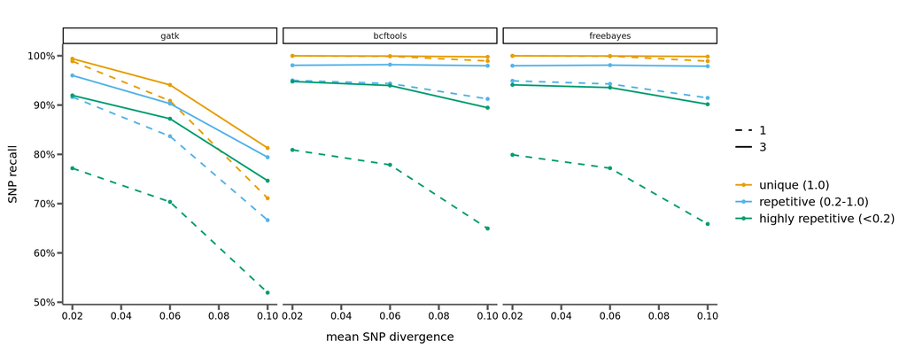

```r
ggplot(mr, aes(divergence, recall, color = map_bin, linetype = iteration)) +
  geom_line(linewidth = 0.8) + geom_point(size = 1.3) +
  scale_color_manual(values = mcols, name = "reference\nmappability") +
  scale_linetype_manual(values = c(`1` = "dashed", `3` = "solid"), name = "iteration") +
  scale_y_continuous(labels = scales::percent) +
  facet_wrap(~caller, nrow = 1) +
  labs(x = "mean SNP divergence", y = "SNP recall") +
  bartheme() + theme(legend.position = "right")
```

*Interpretation.* Iteration lifts the repetitive curves substantially (bcftools highly-repetitive 0.81 → 0.95 at D = 0.02, 0.65 → 0.90 at D = 0.10). The reason is indirect: as the consensus absorbs recovered divergence, the *effective* divergence drops, so reads in semi-repetitive regions carry fewer mismatches and clear the MAPQ filter — the divergence-driven part of the ambiguity is relieved. But a **residual repeat floor remains** (highly-repetitive stays a few points below unique even at iteration 3), because a read that matches two *identical* copies is ambiguous regardless of divergence — that part iteration cannot touch.

# 4 Summary

*Data table + dictionary: `results/s08-mappability-recovery.csv`. GenMap K=100 E=2 on chr19; mappability at the SNP position. s01 SNP-only calls, seed 42.*